# About The Company

Founded by Urska Srsen and Sando Mur, Bella beat is a high-tech company that manufactures health-focused smart products. Its goal is to inform and inspire women around the world to live healthier lives.

#### Analyze Questions

Analyze smart device usage data to gain insights into how consumers use non-Bellabeat smart devices.

1. What are some trends in smart device usage?
2. How could these trends apply to Bellabeat customers?
3. How could these trends help influence Bellabeat marketing strategy?

#### Dataset

This [FitBit dataset](https://www.kaggle.com/arashnic/fitbit) was used to for analysis. This dataset includes a sample set of eligible and consented users logging in their activities between April 12th to May 12th of 2016.

I will be conducting analysis in R and using the ggplot for visualization. (Please look forward to my SQL and Tableau version of this coming soon to a GitHub near you. :-)

To get started, open RStudio and download the aforementioned dataset in [Kaggle](https://www.kaggle.com/arashnic/fitbit).

## Table of Contents

1. Install and Load Pacakges
2. Load CSV file
3. Exploring data
4. Cleaning and Processing Data
5. Summary of Analysis

#### Install and Load Packages

```r
#install packages
install.packages (c("tidyverse", "lubridate", "scales"), repos = "http://cran.us.r-project.org")
```

```
##
##  /var/folders/vy/q5vptsyx73q7364_by3bgs1h0000gn/T//RtmpZeq7YR/downloaded_packages
```

```r
#load packages
library(tidyverse)
library(lubridate)
library(scales)
```

#### Load CSV file.

Note: Make sure the files needed are in the same working directory.

```r
dayActivity <- read_csv("dailyActivity.csv")
daySleep <- read_csv("sleepDay.csv")
```

#### Exploring data

Let’s check out what kind of data these tables show.

```r
colnames(dayActivity)
```

```
##  [1] "Id"                       "ActivityDate"
##  [3] "TotalSteps"               "TotalDistance"
##  [5] "TrackerDistance"          "LoggedActivitiesDistance"
##  [7] "VeryActiveDistance"       "ModeratelyActiveDistance"
##  [9] "LightActiveDistance"      "SedentaryActiveDistance"
## [11] "VeryActiveMinutes"        "FairlyActiveMinutes"
## [13] "LightlyActiveMinutes"     "SedentaryMinutes"
## [15] "Calories"
```

```r
colnames(daySleep)
```

```
## [1] "Id"                 "SleepDay"           "TotalSleepRecords"
## [4] "TotalMinutesAsleep" "TotalTimeInBed"
```

```r
str(dayActivity)
```

```
## spec_tbl_df [940 × 15] (S3: spec_tbl_df/tbl_df/tbl/data.frame)
##  $ Id                      : num [1:940] 1.5e+09 1.5e+09 1.5e+09 1.5e+09 1.5e+09 ...
##  $ ActivityDate            : chr [1:940] "4/12/2016" "4/13/2016" "4/14/2016" "4/15/2016" ...
##  $ TotalSteps              : num [1:940] 13162 10735 10460 9762 12669 ...
##  $ TotalDistance           : num [1:940] 8.5 6.97 6.74 6.28 8.16 ...
##  $ TrackerDistance         : num [1:940] 8.5 6.97 6.74 6.28 8.16 ...
##  $ LoggedActivitiesDistance: num [1:940] 0 0 0 0 0 0 0 0 0 0 ...
##  $ VeryActiveDistance      : num [1:940] 1.88 1.57 2.44 2.14 2.71 ...
##  $ ModeratelyActiveDistance: num [1:940] 0.55 0.69 0.4 1.26 0.41 ...
##  $ LightActiveDistance     : num [1:940] 6.06 4.71 3.91 2.83 5.04 ...
##  $ SedentaryActiveDistance : num [1:940] 0 0 0 0 0 0 0 0 0 0 ...
##  $ VeryActiveMinutes       : num [1:940] 25 21 30 29 36 38 42 50 28 19 ...
##  $ FairlyActiveMinutes     : num [1:940] 13 19 11 34 10 20 16 31 12 8 ...
##  $ LightlyActiveMinutes    : num [1:940] 328 217 181 209 221 164 233 264 205 211 ...
##  $ SedentaryMinutes        : num [1:940] 728 776 1218 726 773 ...
##  $ Calories                : num [1:940] 1985 1797 1776 1745 1863 ...
##  - attr(*, "spec")=
##   .. cols(
##   ..   Id = col_double(),
##   ..   ActivityDate = col_character(),
##   ..   TotalSteps = col_double(),
##   ..   TotalDistance = col_double(),
##   ..   TrackerDistance = col_double(),
##   ..   LoggedActivitiesDistance = col_double(),
##   ..   VeryActiveDistance = col_double(),
##   ..   ModeratelyActiveDistance = col_double(),
##   ..   LightActiveDistance = col_double(),
##   ..   SedentaryActiveDistance = col_double(),
##   ..   VeryActiveMinutes = col_double(),
##   ..   FairlyActiveMinutes = col_double(),
##   ..   LightlyActiveMinutes = col_double(),
##   ..   SedentaryMinutes = col_double(),
##   ..   Calories = col_double()
##   .. )
##  - attr(*, "problems")=<externalptr>
```

```r
str(daySleep)
```

```
## spec_tbl_df [413 × 5] (S3: spec_tbl_df/tbl_df/tbl/data.frame)
##  $ Id                : num [1:413] 1.5e+09 1.5e+09 1.5e+09 1.5e+09 1.5e+09 ...
##  $ SleepDay          : chr [1:413] "4/12/2016 12:00:00 AM" "4/13/2016 12:00:00 AM" "4/15/2016 12:00:00 AM" "4/16/2016 12:00:00 AM" ...
##  $ TotalSleepRecords : num [1:413] 1 2 1 2 1 1 1 1 1 1 ...
##  $ TotalMinutesAsleep: num [1:413] 327 384 412 340 700 304 360 325 361 430 ...
##  $ TotalTimeInBed    : num [1:413] 346 407 442 367 712 320 377 364 384 449 ...
##  - attr(*, "spec")=
##   .. cols(
##   ..   Id = col_double(),
##   ..   SleepDay = col_character(),
##   ..   TotalSleepRecords = col_double(),
##   ..   TotalMinutesAsleep = col_double(),
##   ..   TotalTimeInBed = col_double()
##   .. )
##  - attr(*, "problems")=<externalptr>
```

```r
head(dayActivity)
```

```
## # A tibble: 6 × 15
##        Id ActivityDate TotalSteps TotalDistance TrackerDistance LoggedActivitie…
##     <dbl> <chr>             <dbl>         <dbl>           <dbl>            <dbl>
## 1  1.50e9 4/12/2016         13162          8.5             8.5                 0
## 2  1.50e9 4/13/2016         10735          6.97            6.97                0
## 3  1.50e9 4/14/2016         10460          6.74            6.74                0
## 4  1.50e9 4/15/2016          9762          6.28            6.28                0
## 5  1.50e9 4/16/2016         12669          8.16            8.16                0
## 6  1.50e9 4/17/2016          9705          6.48            6.48                0
## # … with 9 more variables: VeryActiveDistance <dbl>,
## #   ModeratelyActiveDistance <dbl>, LightActiveDistance <dbl>,
## #   SedentaryActiveDistance <dbl>, VeryActiveMinutes <dbl>,
## #   FairlyActiveMinutes <dbl>, LightlyActiveMinutes <dbl>,
## #   SedentaryMinutes <dbl>, Calories <dbl>
```

```r
head(daySleep)
```

```
## # A tibble: 6 × 5
##           Id SleepDay          TotalSleepRecor… TotalMinutesAsle… TotalTimeInBed
##        <dbl> <chr>                        <dbl>             <dbl>          <dbl>
## 1 1503960366 4/12/2016 12:00:…                1               327            346
## 2 1503960366 4/13/2016 12:00:…                2               384            407
## 3 1503960366 4/15/2016 12:00:…                1               412            442
## 4 1503960366 4/16/2016 12:00:…                2               340            367
## 5 1503960366 4/17/2016 12:00:…                1               700            712
## 6 1503960366 4/19/2016 12:00:…                1               304            320
```

```r
n_distinct(dayActivity$Id)
```

```
## [1] 33
```

```r
n_distinct(daySleep$Id)
```

```
## [1] 24
```

Based on this, we can see that there are 33 distinct users who log their activities, and 24 distinct users log their sleep patterns between April 12th - May 12th, 2016.

#### Cleaning and Processing Data

1. All date and time observations include the time of 12:00:00 AM. This data does not help with analysis; rather, it creates noise and makes it more difficult to read. Therefore, we will parse out the redundant time stamp of 12:00:00AM.

```r
daySleep$SleepDay <- mdy_hms(daySleep$SleepDay)

dayActivity$ActivityDate <- mdy(dayActivity$ActivityDate)
```

1. There are a few observations with sedentary minutes to be 1440, which means the users were idle for the entire 24 hours of the day. This has a very low possibility of occurrence, unless the user is gravely ill. Keeping the data will yield inaccurate insights.

I’m using sound judgment to filter out all observations with SedentaryMinutes of more than 1435. I’ve set the cap at 1435, allowing the possibility of the user taking 5 minutes to take care of personal things, even on an inactive day.

```r
dayActivity_new <- dayActivity %>%
  filter(SedentaryMinutes<=1435)
```

1. With that same judgment, I will also filter out all observations with 0 (zero) TotalActiveMins. Again, taking steps to take care of personal things would trigger the active minutes counter, hence an observation of 0 (zero) active minutes has a very low possibility of occurence.

```r
dayActivity_new <- dayActivity_new %>%
  filter((VeryActiveMinutes + FairlyActiveMinutes + LightlyActiveMinutes)>1)
```

1. Create new column “TotalActiveMins” and verify if the sum of “TotalActiveMins” and “SedentaryMins” is 1440. 1440 is the total minutes in a 24 hour period.

```r
dayActivity_new$TotalActiveMins <- dayActivity_new$VeryActiveMinutes + dayActivity_new$FairlyActiveMinutes + dayActivity_new$LightlyActiveMinutes

dayActivity_new$TotalActive_plus_Sedentary <- dayActivity_new$TotalActiveMins + dayActivity_new$SedentaryMinutes
```

1. After sorting TotalActive_plus_Sedentary, we find that majority of the observations did not include an entire day’s worth of activities. Find out how many observations did not include an entire day of activities.

```r
dayActivity_new %>%
  count(dayActivity_new$TotalActive_plus_Sedentary == 1440)
```

```
## # A tibble: 2 × 2
##   `dayActivity_new$TotalActive_plus_Sedentary == 1440`     n
##   <lgl>                                                <int>
## 1 FALSE                                                  458
## 2 TRUE                                                   391
```

391 of 849, or 46%, observations include an entire day’s worth of activity log. 458 observations, or 54%, did not.

1. Filter out observations that has TotalActive_plus_Sedentary < 1200 or 20 hours of logged activities.

```r
dayActivity_new <- dayActivity_new %>%
  filter(TotalActive_plus_Sedentary>=1200)

pivot_Loggers <- dayActivity_new %>%
  group_by(Id) %>%
  select(Id, TotalActiveMins, SedentaryMinutes, TotalActive_plus_Sedentary)

n_distinct(pivot_Loggers$Id)
```

```
## [1] 30
```

We are down to 30 distinct users. Adequate amount of data to use for analysis.

1. Find the average of total sedentary minutes, SedentaryMinutes, and total active minutes, TotalActiveMins, and group by User.

```r
pivot_AVG_active_sedentary <- pivot_Loggers %>%
  group_by(Id) %>%
  summarize (AvgSedentaryMins = mean(SedentaryMinutes), AvgActiveMins = mean(TotalActiveMins))

pivot_AVG_active_sedentary$Total_AVG_active_sedentary <- pivot_AVG_active_sedentary$AvgActiveMins + pivot_AVG_active_sedentary$AvgSedentaryMins

pivot_AVG_ActSed_SELECT <- pivot_AVG_active_sedentary %>%
  group_by(Id) %>%
  select(Id, AvgSedentaryMins, AvgActiveMins)
```

Note: Minutes in daySleep$TotalTimeInBed is included, or a part of, the SedentaryMinutes.

1. Find the average total minutes each user spends asleep and idle, in bed but not asleep.

```r
daySleep$TotalIdleInBed <- daySleep$TotalTimeInBed - daySleep$TotalMinutesAsleep

pivot_AVG_Bed <- daySleep %>%
   group_by(Id) %>%
   summarize (AvgTotalMinsInBed = mean(TotalTimeInBed), AvgTotalMinsAsleep = mean(TotalMinutesAsleep), AvgTotalMinsIdleInBed = mean(TotalIdleInBed))

pivot_AVG_Bed_SELECT <- pivot_AVG_Bed %>%
  group_by(Id) %>%
  select(Id, AvgTotalMinsAsleep, AvgTotalMinsIdleInBed)
```

User 1844505072 is idle in bed a lot longer than the other users. It raises a red flag. After checking the observations in data frame daySleep, it appears to be correct and no other action is needed.

1. Create a new data frame that merge the average minutes active, asleep, and idle in bed, join by “Id”.

```r
final_data <-
pivot_AVG_ActSed_SELECT %>%
inner_join(pivot_AVG_Bed_SELECT)
```

1. Include a new column, SedentaryDifference, to express the difference between sedentary minutes and total minutes asleep and idle in bed.

```r
final_data$AvgSedentaryDifference <- final_data$AvgSedentaryMins - final_data$AvgTotalMinsAsleep - final_data$AvgTotalMinsIdleInBed
```

1. Select data to graph.

```r
final_data_graph <- final_data %>%
  group_by(Id) %>%
  select(Id, AvgActiveMins, AvgTotalMinsAsleep, AvgTotalMinsIdleInBed, AvgSedentaryDifference)
```

1. Then group top third of active users in category “Gold”, middle third as “Silver”, and least active as “Bronze”. Create new column for Category - Gold/Silver/Bronze.

```r
final_data_graph <- final_data_graph %>%
  arrange(desc(AvgActiveMins))

n_distinct(final_data_graph$Id)/3
```

```
## [1] 7
```

```r
final_data_graph$category <- factor(rep(c("Gold","Silver","Bronze"),each=7),levels=c("Gold","Silver","Bronze"))
```

1. Get the average total sleep, idle minutes in bed, active minutes, and sedentary minutes. Group by Category.

```r
pie_data <- final_data_graph %>%
  group_by(category) %>%
  summarize(`Active Mins`=mean(AvgActiveMins),
            `Sleep Mins`=mean(AvgTotalMinsAsleep),
            `Sedentary Mins`=mean(AvgSedentaryDifference),
            `Idle Mins` = mean(AvgTotalMinsIdleInBed))
```

1. Create pie chart.

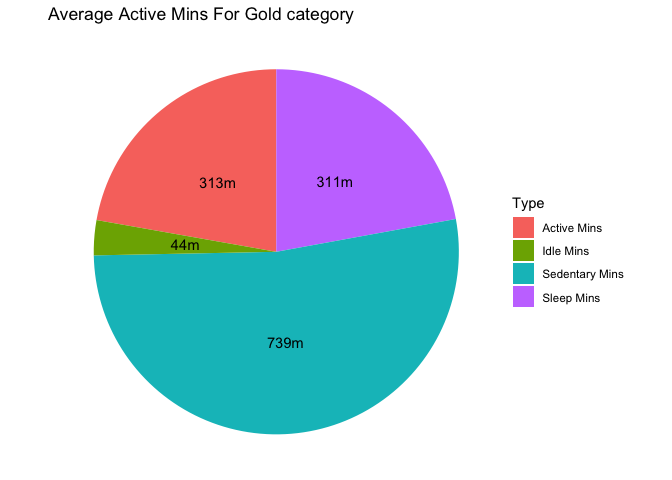

```r
pie_long <- pie_data %>%
  gather("type","value",-category)

#Fitness Activity for Gold category
ggplot(pie_long %>%
         filter(category=="Gold"), aes(x="",y=value, fill=type))+
  geom_bar(width = 1, stat = "identity")+
  coord_polar("y",start = 0)+
  theme_void()+
    geom_text(aes(label = paste0(round((value),0),"m")),
            position = position_stack(vjust = 0.5)) +
  labs(title="Average Active Mins For Gold category",
       fill="Type")
```

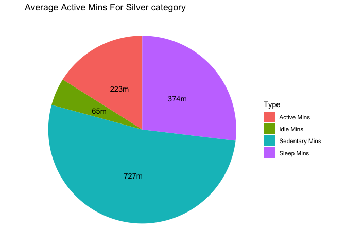

```r
#Fitness Activity for Silver category
ggplot(pie_long %>%
         filter(category=="Silver"), aes(x="",y=value, fill=type))+
  geom_bar(width = 1, stat = "identity")+
  coord_polar("y",start = 0)+
  theme_void()+
    geom_text(aes(label = paste0(round((value),0),"m")),
            position = position_stack(vjust = 0.5)) +
  labs(title="Average Active Mins For Silver category",
       fill="Type")
```

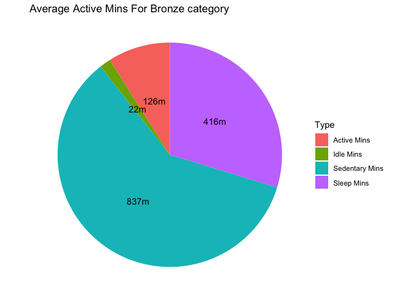

```r
#Fitness Activity for Bronze category
ggplot(pie_long %>%
         filter(category=="Bronze"), aes(x="",y=value, fill=type))+
  geom_bar(width = 1, stat = "identity")+
  coord_polar("y",start = 0)+
  theme_void()+
    geom_text(aes(label = paste0(round((value),0),"m")),
            position = position_stack(vjust = 0.5)) +
  labs(title="Average Active Mins For Bronze category",
       fill="Type")
```

#### Summary of Analysis

##### A Day’s Glance -

*GOLD* - 5 hours 13 mins - active, 5 hours 11 mins - asleep, 44 mins - idle in bed, 12 hours 19 mins - sedentary.

*SILVER* - 3 hours 43 mins - active, 6 hours 14 mins - asleep, 65 mins - idle in bed, 12 hours 7 mins - sedentary.

*BRONZE* - 2 hours 6 mins - active, 6 hours 56 mins - asleep, 22 mins - idle in bed, 13 hours 57 mins - sedentary.

Based on the data, the amount of active minutes is conversely related to the amount of sleep minutes. For example, the most active users, Gold category, logged in the least amount of sleep at 5 hours 11 mins. The least active users, Bronze category, logged in the most amount of sleep at close to 7 hours of sleep.

Although the Gold users’ active minutes are impressive, their sleep patterns are short of what the [CDC suggests.](https://www.cdc.gov/sleep/about_sleep/how_much_sleep.html) While the sleep patterns of the bronze users are aligned with CDC suggestion, their sedentary time is alarming.

Regardless of which category the users fall in, there are ways to improve their lifestyle. One commonality that all users have is the amount of idle time the users spend in bed - between 22-65 minutes. Some users may have trouble going to sleep or getting out of bed when they wake up and will check their smartphones.

##### Strategy suggestions for Stakeholders -

With the assumption that majority of the users check the smartphone during their idle time in bed, Bellabeat should send out health tips notifications to users so they can plan the day ahead. The gold users should receive tips on how to relax and sleep longer, while the bronze users should get motivational tips to get the body moving.

However, it is advised to collect additional data to strategize a better marketing campaign. For instance, collecting data to see if users do in fact check their smartphones in bed will be helpful. Also, the actual time when users go to sleep and idle time would yield a more successful outcome as well. There are users who prefer to check their smartphone before they go to sleep and plan ahead for the next day, while some users check the smartphone the morning of and plan for the day ahead. It is never a bad choice to be considerate.